# Reflection Analytics

Time Period: **Week 6 (Feb 13 - Feb 17)**

This notebook is based on the csv extracted from Quercus from individual "Reflections" pages, by clicking on the "Student Analysis" tab. All student personal data has been removed, and the notebook only deals with aggregated groups (i.e. lecture assigned, engineering discipline).

## Data Sources

General sources (kept between weeks in `class_data` folder):

- `ClassList-20231-APS106H1-S.csv`: sheet from department
- `vader_lexicon.txt`: used for sentiment analysis

## Summary of Analysis

This notebook is broken into the following sub-sections:

1. Student Attendance
2. Student Progress Check
3. Comfort with Topics from Week 6
4. Analysis of single-word and long-answer responses (sentiment analysis).
5. Analysis of Topics Students are confused with.

```python
# define imports
import pandas as pd
import numpy as np

from matplotlib import pyplot as plt
import seaborn as sns
import plotly

from wordcloud import WordCloud
from wordcloud import ImageColorGenerator
from wordcloud import STOPWORDS

import warnings
warnings.filterwarnings('ignore')

plt.style.use('fivethirtyeight')
```

```python
week = 6
```

```python
# read student data
student_data_path = "../class_data/ClassList-20231-APS106H1-S.csv" # changed file to csv, was getting erros on excel
students_df = pd.read_csv(student_data_path)

# read latest df of registered students
register_path = "../class_data/registered_02_28_2023.csv"
register_df = pd.read_csv(register_path)

# read in reflection data
reflection_path = "week{}_raw.csv".format(week)
reflections_df = pd.read_csv(reflection_path)
```

```python
# filter down the students df to only have students currently registered
register_df = register_df.loc[:, "SIS User ID"]
students_df = students_df.merge(register_df, left_on="UTORid", right_on="SIS User ID", how="right")
```

```python
reflections_df.columns
```

```
Index(['name', 'id', 'sis_id', 'section', 'section_id', 'section_sis_id',
       'submitted', 'attempt',
       '3493193: What lecture section(s) did you attend (in person), or do you plan to attend (in person), in Week 6? If multiple sections, please check them all.',
       '1.0',
       '3493194: How many lectures did you attend (in person), or do you plan to attend (in person), in Week 6?',
       '1.0.1',
       '3493195: Which tutorial session(s) did you attend (in person or online), or do you plan to attend (in person or online), in Week 6?',
       '1.0.2',
       '3493196: APS106 provides a number of recordings to make learning material as accessible as possible. Please list the recorded material that you used or plan to use in Week 6.\n\nIf you are not attending lectures and tutorials in person or online but are watching the recordings, this is where…
       '1.0.3',
       '3493201: InWeek 6 during the 3rd lecture of the week, you worked throughDesign Problem 3: Madlibs. Design Problems show the application of the topics covered in previous lectures to solve a practical engineering problem. Did this Design Problem help improve your understanding of the course m…
       '1.0.4',
       '3493197: Did you spend or plan to spend any time working onPractice ProblemsinWeek 6?',
       '1.0.5',
       '3493198: At the end ofWeek 6, do you feel on top of the course material or are you feeling that you're falling behind?',
       '1.0.6',
       '3493199: Please write one word that describes how you feel afterWeek 6of APS106.',
       '1.0.7',
       '3493200: Please list any and all topics that you are confused about or struggling with. List topics of confusion separated by commas. If you are not confused by anything, please leave it blank.\nExample: functions, variables, syntax errors, print, operators',
       '1.0.8',
       '3495832: This week in lectures we learned about for loops. Please indicate your level of understanding regarding the concept of for loops.',
       '1.0.9', 'n correct', 'n incorrect', 'score'],
      dtype='object')
```

```python
# 1 -data cleansing. Remove the "attempt" and question score columns auto-generated by quercus
reflections_df = reflections_df.drop(columns=['attempt','1.0', '1.0.1','1.0.2','1.0.3','1.0.4',
        '1.0.4','1.0.5','1.0.6','1.0.7','1.0.8','1.0.9','n correct', 'n incorrect', 'score'])

# 2 - rename columns in dataframe so are shorter
current_column_names = list(reflections_df.columns)

column_names = {
    current_column_names[7]: "lecture_sections",
    current_column_names[8]: "lecture_count",
    current_column_names[9]: "tutorial_sections",
    current_column_names[10]: "recorded_materials",
    current_column_names[11]: "design_problem",
    current_column_names[12]: "practice_problems",
    current_column_names[13]: "progress_check",
    current_column_names[14]: "comment_one_word",
    current_column_names[15]: "confused_topics",
    current_column_names[16]: "for_loop_check"
}

reflections_df.rename(columns=column_names, inplace=True)

# 3 - join reflection data with student data based on UTORid
combined_df = reflections_df.merge(students_df, left_on = "sis_id", right_on = "UTORid", how="left")

# 4 - rename disciplines from the POSt Code
combined_df['POSt Code'] = combined_df['POSt Code'].str.rstrip("X")

disciplines = {
    "AECHEBASC": "Chemical",
    "AECIVBASC": "Civil",
    "AEMECBASC": "Mechanical",
    "AELMEBASC": "Mineral",
    "AEINDBASC": "Industrial",
    "AEMMSBASC": "Materials",
    "AEENGBASC": "Track-One",
    "AE   NDEGI": "Non-Degree"
    }

combined_df['discipline'] = combined_df['POSt Code'].map(disciplines)
combined_df = combined_df.drop(columns=['sis_id','UTORid','name', 'Surname', 'Given Name', #'Person ID',
       'Title', 'Year', 'Reg. Sts', 'Enr. Sts','Email Address','id' ])

# 5 - get count of lecture sections attended + reformat to match student information sheet
combined_df['LEC0101_attended'] = np.where(combined_df['lecture_sections'].str.contains("LEC01"), "LEC0101", False)
combined_df['LEC0102_attended'] = np.where(combined_df['lecture_sections'].str.contains("LEC02"), "LEC0102", False)
combined_df['LEC0103_attended'] = np.where(combined_df['lecture_sections'].str.contains("LEC03"), "LEC0103", False)

combined_df['lecture_assigned'] = np.where(np.logical_or(combined_df['LEC0103_attended'] == combined_df['Lecture'], np.logical_or(combined_df['LEC0101_attended'] == combined_df['Lecture'],
            combined_df['LEC0102_attended'] == combined_df['Lecture'])), True, False) # does not account for students not in excel!


### ADD POLARITY TO LONG ANSWERS ###

# 1 - remove all punctuation from student paragraph, lower all strings
punctuations = '!"#$%&\'()*+-.:;<=>?@@[\\]^_`{|}~“'
esc_char = "\xa0"

def remove_punctuations(text):
    text = str(text)
    for x in punctuations:
        if (x in text):
            text=text.replace(x,"")
    text = text.replace(esc_char,"")
    text = text.replace('\n',"")
    text = text.replace('\t',"")
    return text

combined_df['cleaned_answer'] = combined_df.apply(lambda row: remove_punctuations(text=row['comment_one_word']),axis=1)
combined_df['cleaned_answer'] = combined_df['cleaned_answer'].str.lower()

# 2 - each word from the reflection will be separated into its own row in a new dataframe
word_lookup = (combined_df['cleaned_answer'].str.split(' ', expand=True).stack().reset_index(name='word'))
word_lookup = word_lookup[word_lookup.word != '']
word_lookup = word_lookup.set_index('level_0',drop=True).rename(columns={'level_1':'num'})


# 3 - introduce lexicon to look up polarity values for each word
file = open('../class_data/vader_lexicon.txt', 'r').read().split('\n')
lexicon_text = [x for x in file[0:]]

lexicon =  pd.DataFrame(lexicon_text,columns=['data'])
lexicon = lexicon['data'].str.split('\t',expand=True)
lexicon = lexicon[[0,1]].rename(columns={0: "word", 1: "polarity"}).set_index('word')

# 4 - look up each word inside the long answer, assign a polarity
word_lookup = word_lookup.join(lexicon, on ='word')
word_lookup.fillna(0, inplace=True)

# 5 - aggregate dataframe back to sum polarity per long answer
word_lookup[["polarity"]] = word_lookup[["polarity"]].apply(pd.to_numeric)
polarity = word_lookup.groupby(['level_0'])['polarity'].sum().to_frame()

# 6 - join polarity data back into combined_df
combined_df = combined_df.join(polarity)

# View DataFrame
combined_df.head(3)
```

|  | section | section_id | section_sis_id | submitted | lecture_sections | lecture_count | tutorial_sections | recorded_materials | design_problem | practice_problems | ... | Tutorial | Practical | SIS User ID | discipline | LEC0101_attended | LEC0102_attended | LEC0103_attended | lecture_assigned | cleaned_answer | polarity |
| --- | --- | --- | --- | --- | --- | --- | --- | --- | --- | --- | --- | --- | --- | --- | --- | --- | --- | --- | --- | --- | --- |
| 0 | APS106H1-S-PRA0101-20231, APS106H1-S-LEC0101-2... | 272286, 272280, 272303 | APS106H1-S-PRA0101-20231, APS106H1-S-LEC0101-2... | 2023-02-27 16:00:00 UTC | NaN | NaN | NaN | NaN | NaN | NaN | ... | TUT0101 | PRA0101 | shensih2 | Chemical | LEC0101 | LEC0102 | LEC0103 | True | nan | 0.0 |
| 1 | APS106H1-S-LEC0102-20231, APS106H1-S-PRA0105-2... | 272282, 272295, 272311 | APS106H1-S-LEC0102-20231, APS106H1-S-PRA0105-2... | 2023-02-27 15:51:28 UTC | LEC02 - Beck | 2.0 | TUT0105 (Monday\, 12:00 - 13:00) | LEC02 - Beck Lecture Recording | Very Helpful | Yes | ... | TUT0105 | PRA0105 | nguy3244 | Mechanical | False | LEC0102 | False | True | ok | 1.4 |
| 2 | APS106H1-S-PRA0105-20231, APS106H1-S-TUT0105-2... | 272295, 272311, 272282 | APS106H1-S-PRA0105-20231, APS106H1-S-TUT0105-2... | 2023-02-27 15:47:30 UTC | LEC02 - Beck | 3.0 | Did Not/Will Not Attend | LEC02 - Beck Lecture Recording | Very Helpful | No | ... | TUT0105 | PRA0105 | zha12375 | Mechanical | False | LEC0102 | False | True | good | 1.9 |

3 rows × 27 columns

```python
# export cleaned dataframe into csv
combined_df.to_csv('reflection{}.csv'.format(week))
```

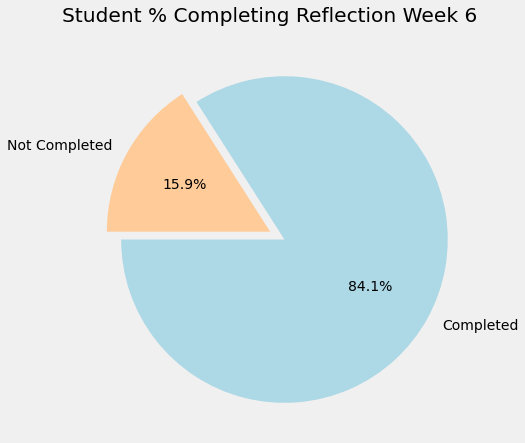

```python
# number of students who completed reflection
completed = len(reflections_df)
not_complete = len(students_df) - completed

# how many students in each tutorial section
plt.figure(figsize=(7,7))
plt.title("Student % Completing Reflection Week {}".format(week))

values = [completed, not_complete]
name = ["Completed", "Not Completed"]

colors = ['#ADD8E6','#ffcc99','#98AFC7','#ff9999','#d7edb9','#c4bcc0','#67805c','#ab446c','#41734f','#eb4034']
explode = (0.1, 0)

plt.pie(values, labels=name, colors=colors, startangle=-180,autopct='%1.1f%%',explode=explode)
plt.show()
```

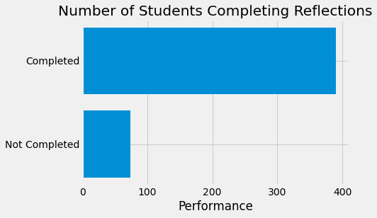

```python
fig, ax = plt.subplots()

# Example data
labels = ('Completed', 'Not Completed')
y_pos = np.arange(len(labels))
values = [completed, not_complete]

ax.barh(y_pos, values, align='center')
ax.set_yticks(y_pos, labels=labels)
ax.invert_yaxis()  # labels read top-to-bottom
ax.set_xlabel('Performance')
ax.set_title('Number of Students Completing Reflections')

plt.show()
```

# 1. Student Attendence During Current Week

[figure not shown]

```python
fig, axs = plt.subplots(1, 3, figsize=(14, 7))

fig.suptitle("Week {}: Frequency of Student Attendance Per Lecture Section".format(week))

column_list = ["LEC0101_attended","LEC0102_attended","LEC0103_attended"]
lecture_list = [ x.split('_')[0] for x in column_list]

lecture_name = {
    "LEC0101": "Kinsella & Goodfellow",
    "LEC0102": "Beck",
    "LEC0103": "Rosu"
}

for index, value in enumerate(column_list):
    data = combined_df[combined_df[value]==lecture_list[index]]
    sns.countplot(x=value, hue="lecture_count", data=data, ax=axs[index])
    axs[index].get_xaxis().set_visible(False)
    axs[index].set_ylim(0,210)
    axs[index].set_title(lecture_name[lecture_list[index]])

    values=data['lecture_count'].value_counts().values
    values = values[::-1]

    for i, p in enumerate(axs[index].patches):
        height = p.get_height()
        axs[index].text(p.get_x()+p.get_width()/2., height + 0.1,values[i],ha="center")


plt.show()
```

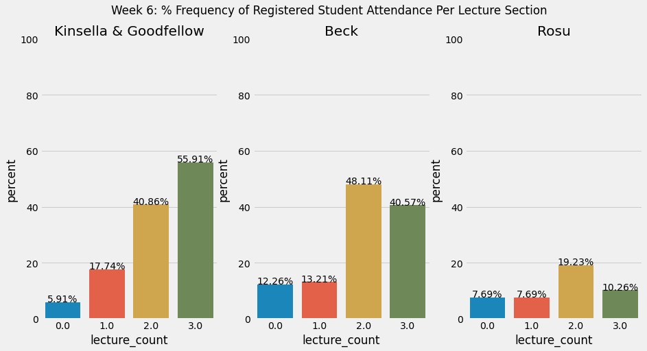

```python
fig, axs = plt.subplots(1, 3, figsize=(14, 7))

fig.suptitle("Week {}: % Frequency of Registered Student Attendance Per Lecture Section ".format(week))

column_list = ["LEC0101_attended","LEC0102_attended","LEC0103_attended"]
lecture_list = [ x.split('_')[0] for x in column_list]

lecture_name = {
    "LEC0101": "Kinsella & Goodfellow",
    "LEC0102": "Beck",
    "LEC0103": "Rosu"
}

assigned_lecture = [
    len(combined_df[combined_df["Lecture"]=="LEC0101"]),
    len(combined_df[combined_df["Lecture"]=="LEC0102"]),
    len(combined_df[combined_df["Lecture"]=="LEC0103"])
]

for index, value in enumerate(column_list):

    #filter down the dataframe only to the specific lecturer
    df_temp = combined_df[combined_df[value]==lecture_list[index]]
    df_temp = df_temp.groupby("lecture_count").agg('count')

    df_temp =  df_temp[["section"]].copy().reset_index()
    df_temp['percent'] = df_temp['section'] / assigned_lecture[index] * 100


    sns.barplot(data=df_temp, x="lecture_count", y="percent", ax=axs[index])
    axs[index].set_ylim(0,100)
    axs[index].set_title(lecture_name[lecture_list[index]])

    values = list(df_temp['percent'])

    for i, p in enumerate(axs[index].patches):
        height = p.get_height()
        axs[index].text(p.get_x()+p.get_width()/2., height + 0.1,"{}%".format(round((values[i]),2)),ha="center")

plt.show()
```

```
posx and posy should be finite values
posx and posy should be finite values
posx and posy should be finite values
posx and posy should be finite values
```

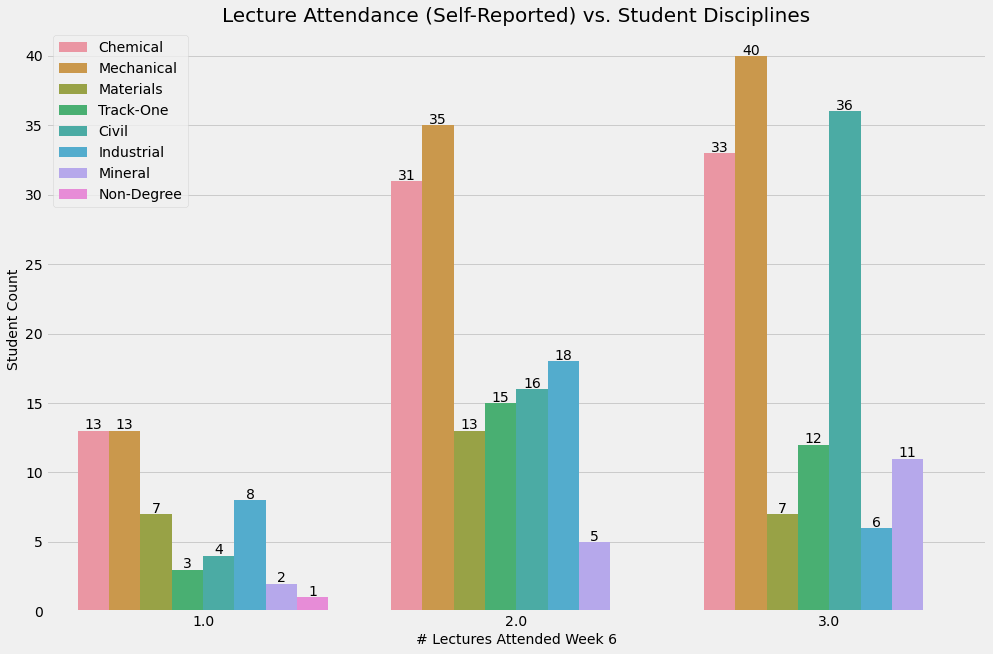

```python
plt.figure(figsize=(15,10))
plt.title('Lecture Attendance (Self-Reported) vs. Student Disciplines', fontsize = 20)
ax = sns.countplot(x="lecture_count", hue="discipline", data=combined_df[combined_df['lecture_count']!=0])

# for container in ax.containers:
#     ax.bar_label(container)

for i, p in enumerate(ax.patches):
    height = p.get_height()
    ax.text(p.get_x()+p.get_width()/2., height + 0.1,"{}".format(str(p).split(',')[3].split('=')[1]),ha="center")

ax.set_ylabel('Student Count', fontsize=14)
ax.set_xlabel('# Lectures Attended Week {}'.format(week), fontsize=14)
plt.legend(loc='upper left')
plt.show()
```

One note: these percentages are based on the students who **answered the survey!**

```
posx and posy should be finite values
posx and posy should be finite values
posx and posy should be finite values
posx and posy should be finite values
```

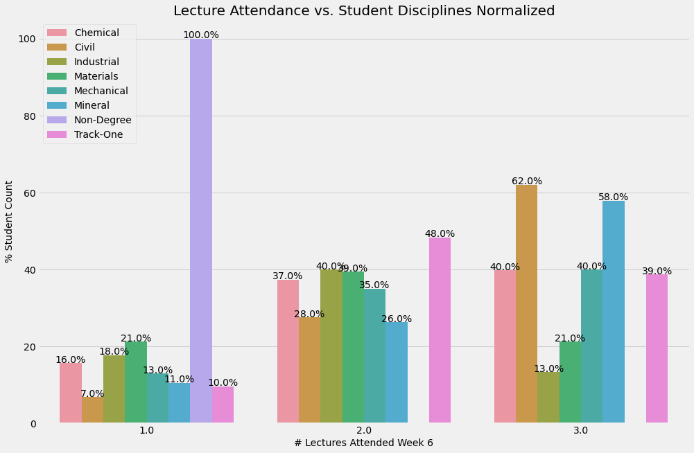

```python
#define the total counts per discipline
total_students = dict(combined_df['discipline'].value_counts())

#define separate dataframe based on student discipline + attendance counts
agg_students = combined_df.groupby(['discipline','lecture_count']).count()
agg_students = agg_students.reset_index()
agg_students =  agg_students[["discipline","lecture_count","section"]].copy()
#agg_students = agg_students[agg_students['lecture_count']!=0]

agg_students['total_count'] = agg_students['discipline'].map(total_students)
agg_students['percent'] = agg_students['section'] / agg_students['total_count'] * 100

plt.figure(figsize=(15,10))
plt.title('Lecture Attendance vs. Student Disciplines Normalized', fontsize = 20)
ax = sns.barplot(x="lecture_count", y="percent", hue="discipline", data=agg_students[agg_students['lecture_count']!=0])

# add labels
for i, p in enumerate(ax.patches):
    height = p.get_height()
    ax.text(p.get_x()+p.get_width()/2., height + 0.1,"{}%".format(round(height,0)),ha="center")

ax.set_ylabel('% Student Count', fontsize=14)
ax.set_xlabel('# Lectures Attended Week {}'.format(week), fontsize=14)

plt.legend(loc='upper left')

plt.show()
```

[figure not shown]

```python
fig, axs = plt.subplots(1, 3, figsize=(14, 7))

fig.suptitle("Week {}: Student Attendance Per Lecture Section Per Engineering Discipline".format(week))

column_list = ["LEC0101_attended","LEC0102_attended","LEC0103_attended"]
lecture_list = [ x.split('_')[0] for x in column_list]

lecture_name = {
    "LEC0101": "Kinsella & Goodfellow",
    "LEC0102": "Beck",
    "LEC0103": "Rosu"
}

# convert discipline columns to numeric (so consistent between lecture sections)
disciplines_num = {
    "Chemical":1,
    "Civil":2,
    "Mechanical":3,
    "Mineral":4,
    "Industrial":5,
    "Materials":6,
    "Track-One":7,
    "Non-Degree":8
    }

combined_df['discipline_num'] = combined_df['discipline'].map(disciplines_num)

for index, value in enumerate(column_list):
    sns.countplot(x=value, hue="discipline_num", data=combined_df[combined_df[value]==lecture_list[index]], ax=axs[index])
    axs[index].get_xaxis().set_visible(False)
    axs[index].set_ylim(0,200)
    axs[index].set_title(lecture_name[lecture_list[index]])
    axs[index].legend(labels = list(disciplines_num.keys()))

    for i, p in enumerate(axs[index].patches):
        height = p.get_height()
        axs[index].text(p.get_x()+p.get_width()/2., height + 0.1,"{}".format(str(p).split(',')[3].split('=')[1][0:4]),ha="center")

    if index == 0:
        axs[index].set_ylabel('Student Count', fontsize=14)
    else:
        axs[index].set_ylabel(' ')

    #axs[index].set_xlabel('Disciplines', fontsize=14)

plt.show()
```

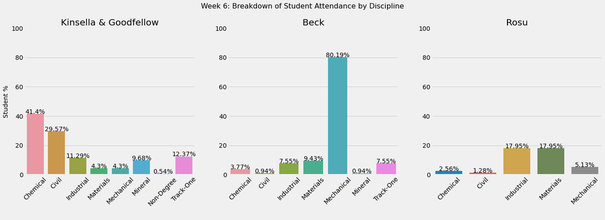

```python
fig, axs = plt.subplots(1, 3, figsize=(19, 7))

fig.suptitle("Week {}: Breakdown of Student Attendance by Discipline".format(week), size =16)

column_list = ["LEC0101_attended","LEC0102_attended","LEC0103_attended"]
lecture_list = [ x.split('_')[0] for x in column_list]

lecture_name = {
    "LEC0101": "Kinsella & Goodfellow",
    "LEC0102": "Beck",
    "LEC0103": "Rosu"
}

assigned_lecture = [
    len(combined_df[combined_df["Lecture"]=="LEC0101"]),
    len(combined_df[combined_df["Lecture"]=="LEC0102"]),
    len(combined_df[combined_df["Lecture"]=="LEC0103"])
]

for index, value in enumerate(column_list):

    #filter down the dataframe only to the specific lecturer
    df_temp = combined_df[combined_df[value]==lecture_list[index]]
    df_temp = df_temp.groupby("discipline").agg('count')

    df_temp =  df_temp[["section"]].copy().reset_index()
    df_temp['percent'] = df_temp['section'] / assigned_lecture[index] * 100


    sns.barplot(data=df_temp, x="discipline", y="percent", ax=axs[index])
    axs[index].set_ylim(0,100)
    axs[index].set_title(lecture_name[lecture_list[index]])
    axs[index].set_xticklabels(labels = df_temp['discipline'], rotation=45)

    values = list(df_temp['percent'])

    for i, p in enumerate(axs[index].patches):
        height = p.get_height()
        axs[index].text(p.get_x()+p.get_width()/2., height + 0.1,"{}%".format(round((values[i]),2)),ha="center")

    axs[index].set_xlabel(' ')
    if index == 0:
        axs[index].set_ylabel('Student %', fontsize=14)
    else:
        axs[index].set_ylabel(' ')


fig.tight_layout()
plt.show()
```

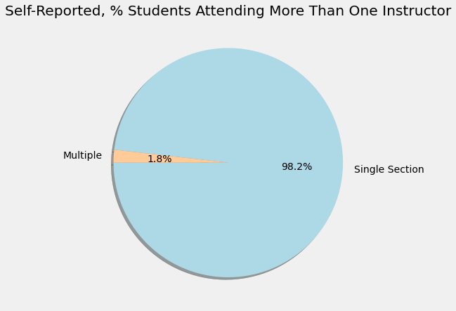

```python
# how many students attended more than one instructor session last week (i.e. both Kinsella and Rosu lectures)
plt.figure(figsize=(7,7))
plt.title("Self-Reported, % Students Attending More Than One Instructor")

combined_df['multiple_sections'] = combined_df['lecture_sections'].str.contains(",")

name = ['Single Section', 'Multiple']
values = combined_df['multiple_sections'].value_counts()
# print(values)

colors = ['#ADD8E6','#ffcc99','#98AFC7','#ff9999','#ffcc99']

plt.pie(values, labels=name, colors=colors, startangle=-180,autopct='%1.1f%%',shadow=True)
plt.show()
```

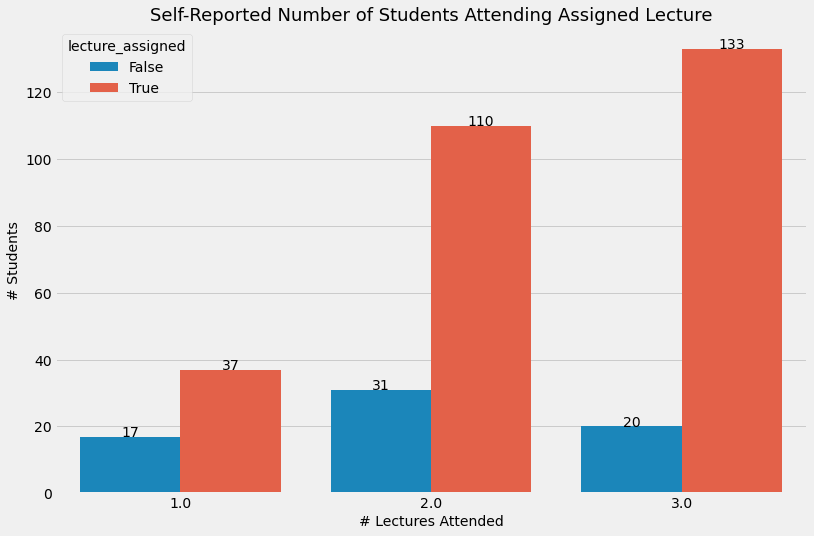

```python
# how many students are not attending their assigned lecture section?
plt.figure(figsize=(12,8))

plt.title('Self-Reported Number of Students Attending Assigned Lecture', fontsize = 18)
ax = sns.countplot(x="lecture_count", hue="lecture_assigned", data=combined_df[combined_df['lecture_count']>0])

for i, p in enumerate(ax.patches):
    height = p.get_height()
    ax.text(p.get_x()+p.get_width()/2., height + 0.1, height ,ha="center")

ax.set_xlabel('# Lectures Attended', fontsize=14)
ax.set_ylabel('# Students', fontsize=14)

plt.show()
```

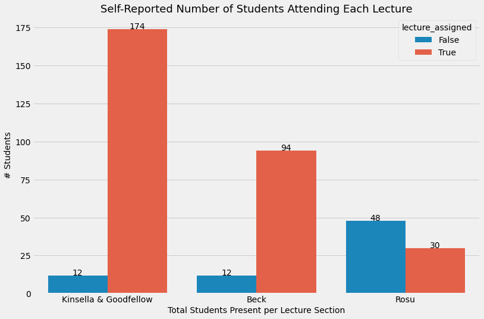

```python
# how many students are not attending their assigned lecture section?
plt.figure(figsize=(12,8))

lecture_name = {
    "LEC0101": "Kinsella & Goodfellow",
    "LEC0102": "Beck",
    "LEC0103": "Rosu"
}

plt.title('Self-Reported Number of Students Attending Each Lecture', fontsize = 18)
combined_df['lecture_name_assigned'] = combined_df['Lecture'].map(lecture_name)

ax = sns.countplot(x="lecture_name_assigned", hue="lecture_assigned", data=combined_df)

for i, p in enumerate(ax.patches):
    height = p.get_height()
    ax.text(p.get_x()+p.get_width()/2., height + 0.1, height ,ha="center")

ax.set_xlabel('Total Students Present per Lecture Section', fontsize=14)
ax.set_ylabel('# Students', fontsize=14)

plt.show()
```

```
10
```

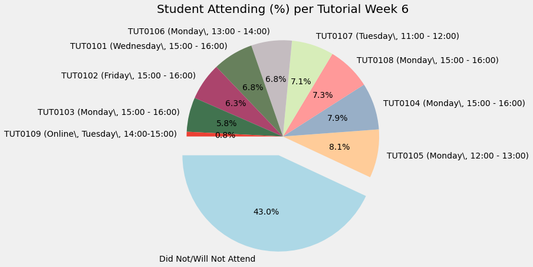

```python
# how many students in each tutorial section
plt.figure(figsize=(7,7))
plt.title("Student Attending (%) per Tutorial Week {}".format(week))

name = list(dict(combined_df.tutorial_sections.value_counts()).keys())[0:10]
values = list(dict(combined_df.tutorial_sections.value_counts()).values())[0:10]

print(len(values))

colors = ['#ADD8E6','#ffcc99','#98AFC7','#ff9999','#d7edb9','#c4bcc0','#67805c','#ab446c','#41734f','#eb4034']
#explode = (0.2, 0, 0,0,0,0,0,0,0,0,0,0,0,0,0)
explode = [ 0 for i in range(10)]
explode[0] = 0.2

plt.pie(values, labels=name, colors=colors, startangle=-180,autopct='%1.1f%%',explode=explode)
plt.show()
```

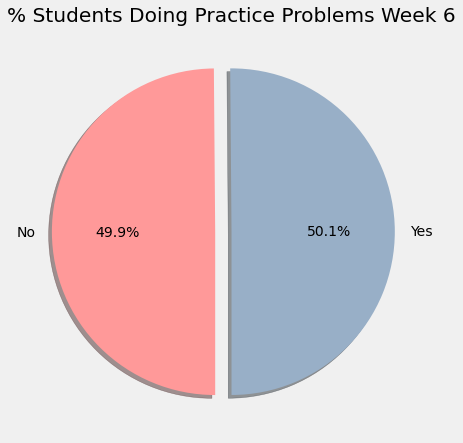

```python
# how many students did practice problems
plt.figure(figsize=(7,7))
plt.title("% Students Doing Practice Problems Week {}".format(week))

name = list(dict(combined_df.practice_problems.value_counts()).keys())
values = list(dict(combined_df.practice_problems.value_counts()).values())

colors = ['#98AFC7','#ff9999','#d7edb9','#c4bcc0','#67805c','#ab446c','#41734f']
explode = (0, 0.1)

plt.pie(values, labels=name, colors=colors, startangle=-90,autopct='%1.1f%%',explode=explode, shadow=True)
plt.show()
```

# Student Use of Online Materials

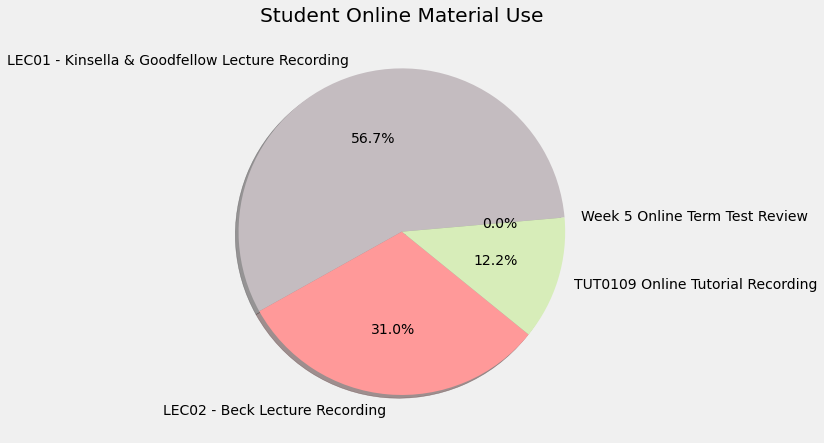

```python
# how are students using onlin materials
plt.figure(figsize=(7,7))
plt.title("Student Online Material Use")

names = [
    'LEC01 - Kinsella & Goodfellow Lecture Recording',
    "LEC02 - Beck Lecture Recording",
    "TUT0109 Online Tutorial Recording",
    "Week 5 Online Term Test Review"
]

values = []

for name in names:
    df_filt = combined_df[combined_df['recorded_materials'].str.contains(name)==True]
    values.append(len(df_filt))

colors = ['#c4bcc0','#ff9999','#d7edb9','#98AFC7']

plt.pie(values, labels=names, colors=colors, startangle=5,autopct='%1.1f%%', shadow=True)
plt.show()
```

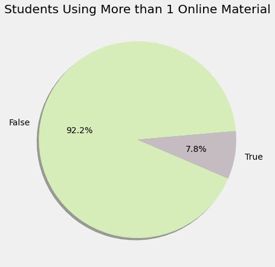

```python
# students using more than 1 online resource
plt.figure(figsize=(7,7))
plt.title("Students Using More than 1 Online Material")

combined_df['multiple_online'] =  combined_df['recorded_materials'].str.contains(',')

name = list(dict(combined_df.multiple_online.value_counts()).keys())
values = list(dict(combined_df.multiple_online.value_counts()).values())

colors = ['#d7edb9','#c4bcc0','#ff9999','#98AFC7']

plt.pie(values, labels=name, colors=colors, startangle=5,autopct='%1.1f%%', shadow=True)
plt.show()
```

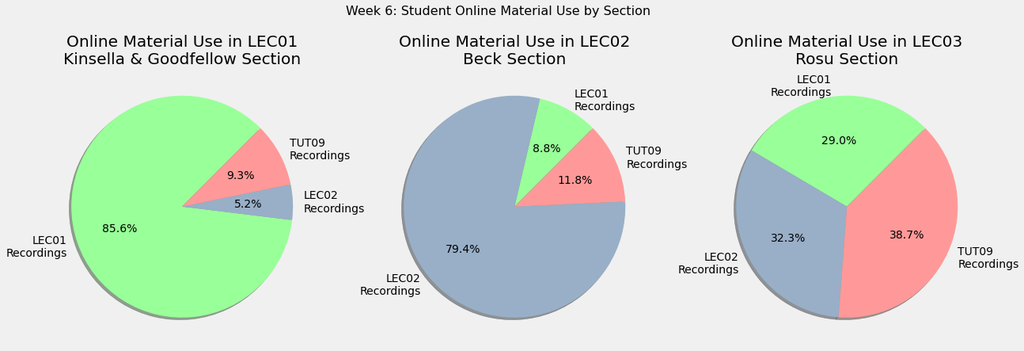

```python
fig, axs = plt.subplots(1, 3, figsize=(19, 7))

fig.suptitle("Week {}: Student Online Material Use by Section".format(week), size =16)

column_list = ["LEC01","LEC02","LEC03"]
lecture_list = ["LEC01\nKinsella & Goodfellow", "LEC02\nBeck", "LEC03\nRosu"]

names = [
    'LEC01 - Kinsella & Goodfellow Lecture Recording',
    "LEC02 - Beck Lecture Recording",
    "TUT0109 Online Tutorial Recording",
]

for index, value in enumerate(column_list):

    #filter down the dataframe only to the specific lecturer
    df_temp = combined_df[combined_df['lecture_sections'].str.contains(value)==True]

    values = []
    for name in names:
        df_filt = df_temp[df_temp['recorded_materials'].str.contains(name)==True]
        values.append(len(df_filt))

    colors = ['#99ff99','#98AFC7','#ff9999','#ffcc99']

    #ax[index].pie(data_per, labels = [round(i,2) for i in (list(data_per))])

    labels = ['LEC01\nRecordings', 'LEC02\nRecordings', 'TUT09\nRecordings']

    axs[index].pie(values, labels = labels, colors = colors, autopct='%1.1f%%', shadow=True, startangle=45)
    axs[index].title.set_text("Online Material Use in {} Section".format(str(lecture_list[index])))

plt.show()
```

# Student Course Progress Check

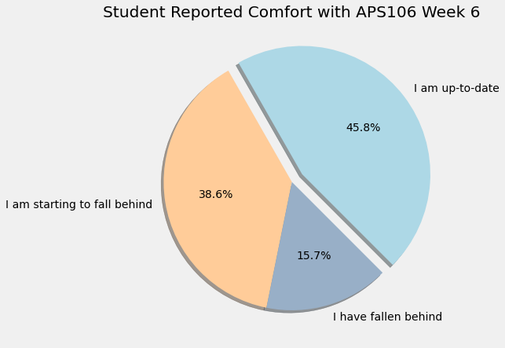

```python
# how are students doing in week 2?
plt.figure(figsize=(7,7))
plt.title("Student Reported Comfort with APS106 Week {}".format(week))

name = list(dict(combined_df.progress_check.value_counts()).keys())
values = list(dict(combined_df.progress_check.value_counts()).values())

colors = ['#ADD8E6','#ffcc99','#98AFC7','#ff9999','#d7edb9','#c4bcc0','#67805c','#ab446c']
explode = (0.1, 0, 0)

plt.pie(values, labels=name, colors=colors, startangle=-45,autopct='%1.1f%%',explode=explode, shadow=True)
plt.show()
```

```
posx and posy should be finite values
posx and posy should be finite values
posx and posy should be finite values
posx and posy should be finite values
```

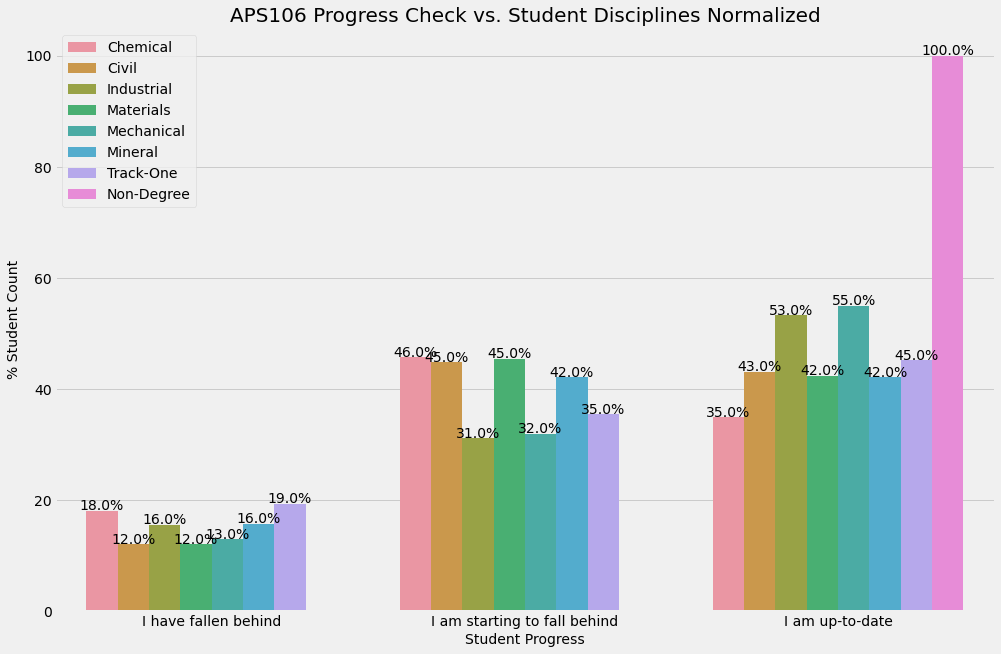

```python
#define the total counts per discipline
total_students = dict(combined_df['discipline'].value_counts())

#define separate dataframe based on student discipline + attendance counts
agg_students = combined_df.groupby(['discipline','progress_check']).count()
agg_students = agg_students.reset_index()
agg_students =  agg_students[["discipline","progress_check","section"]].copy()
#agg_students = agg_students[agg_students['lecture_count']!=0]

agg_students['total_count'] = agg_students['discipline'].map(total_students)
agg_students['percent'] = agg_students['section'] / agg_students['total_count'] * 100

progress_numeric = {
    'I have fallen behind': 0,
    'I am starting to fall behind': 1,
    'I am up-to-date': 2
}

agg_students['progress_numeric'] = agg_students['progress_check'].map(progress_numeric)

agg_students = agg_students.sort_values(by=['progress_numeric','discipline'])

plt.figure(figsize=(15,10))
plt.title('APS106 Progress Check vs. Student Disciplines Normalized', fontsize = 20)
ax = sns.barplot(x="progress_check", y="percent", hue="discipline", data=agg_students)

# add labels
for i, p in enumerate(ax.patches):
    height = p.get_height()
    ax.text(p.get_x()+p.get_width()/2., height + 0.1,"{}%".format(round(height,0)),ha="center")

ax.set_ylabel('% Student Count', fontsize=14)
ax.set_xlabel('Student Progress', fontsize=14)

plt.legend(loc='upper left')

plt.show()
```

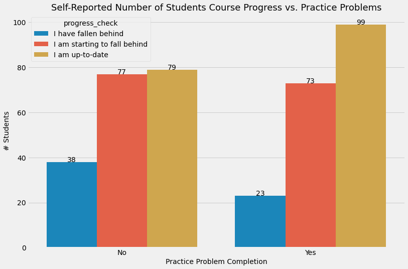

```python
# how many students are not attending their assigned lecture section?
plt.figure(figsize=(12,8))

progress_numeric = {
    'I have fallen behind': 0,
    'I am starting to fall behind': 1,
    'I am up-to-date': 2
}

combined_df['progress_numeric'] = combined_df['progress_check'].map(progress_numeric)

combined_df = combined_df.sort_values(by=['progress_numeric'])

plt.title('Self-Reported Number of Students Course Progress vs. Practice Problems', fontsize = 18)

ax = sns.countplot(x="practice_problems", hue="progress_check", data=combined_df)

for i, p in enumerate(ax.patches):
    height = p.get_height()
    ax.text(p.get_x()+p.get_width()/2., height + 0.1, height ,ha="center")

ax.set_xlabel('Practice Problem Completion', fontsize=14)
ax.set_ylabel('# Students', fontsize=14)

plt.show()
```

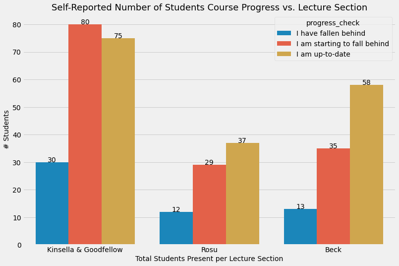

```python
# how many students are not attending their assigned lecture section?
plt.figure(figsize=(12,8))

progress_numeric = {
    'I have fallen behind': 0,
    'I am starting to fall behind': 1,
    'I am up-to-date': 2
}

combined_df['progress_numeric'] = combined_df['progress_check'].map(progress_numeric)

combined_df = combined_df.sort_values(by=['progress_numeric','discipline'])

plt.title('Self-Reported Number of Students Course Progress vs. Lecture Section', fontsize = 18)

ax = sns.countplot(x="lecture_name_assigned", hue="progress_check", data=combined_df)

for i, p in enumerate(ax.patches):
    height = p.get_height()
    ax.text(p.get_x()+p.get_width()/2., height + 0.1, height ,ha="center")

ax.set_xlabel('Total Students Present per Lecture Section', fontsize=14)
ax.set_ylabel('# Students', fontsize=14)

plt.show()
```

# Individual Topics Covered During the Week

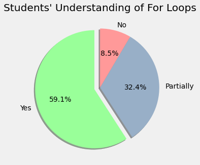

```python
# check general % of students comfortable with the new topics

columns = ['for_loop_check']
titles = ['For Loops']

fig = plt.figure(figsize=(5, 5))

column = dict(combined_df[columns[0]].value_counts())
data = list(column.values())
labels = ['Yes', 'Partially', 'No']

explode = (0.1, 0, 0)

total = sum(data)
data_per = data/total*100

colors = ['#99ff99','#98AFC7','#ff9999','#ffcc99']

plt.pie(data_per, labels = labels, colors = colors, autopct='%1.1f%%', shadow=True, startangle=90,explode=explode)
plt.title("Students' Understanding of {}".format(str(titles[0])))

plt.show()

# fig, ax = plt.subplots(1,len(columns), figsize=(20, 30))


# for index, value in enumerate(columns):
#     column = dict(combined_df[value].value_counts())
#     data = list(column.values())
#     labels = ['Yes', 'Partially', 'No']

#     explode = (0.1, 0, 0)

#     total = sum(data)
#     data_per = data/total*100

#     colors = ['#99ff99','#98AFC7','#ff9999','#ffcc99']

#     #ax[index].pie(data_per, labels = [round(i,2) for i in (list(data_per))])

#     ax[index].pie(data_per, labels = labels, colors = colors, autopct='%1.1f%%', shadow=True, startangle=90,explode=explode)
#     ax[index].title.set_text("Students' Understanding of {}".format(str(titles[index])))


plt.show()
```

[figure not shown]

```python
# comfort level correlated with attendance level

fig = plt.figure(figsize=(12, 7))

plt.title("Week {}: Student Attendance vs Comfort with For Loops".format(week))

numeric = {
    'I do not understand': 0,
    'I somewhat understand': 1,
    'I completely understand': 2
}

new_column = [ x + '_numeric' for x in columns]

# for index, value in enumerate(columns):

combined_df[new_column[0]] = combined_df[columns[0]].map(numeric)

sorted_df = combined_df.sort_values(by=[new_column[0]])

ax = sns.countplot(x="lecture_count", hue="lecture_name_assigned", data=sorted_df)
# axs[index].set_title("{}".format(titles[index]))

for i, p in enumerate(ax.patches):
    height = p.get_height()
    ax.text(p.get_x()+p.get_width()/2., height + 0.1, height ,ha="center")

# fig.set_ylabel("# Students", fontsize = 14)

plt.show()
```

# Word Cloud: Single Word for How Students are Feeling

```python
# all the answers from the students in one-word "how are you feeling", which are unqiue
combined_df['comment_one_word'].unique()[20:24]
```

```
array(['Good and excited', 'can’t keep up', 'Decent\xa0', 'Nervous'],
      dtype=object)
```

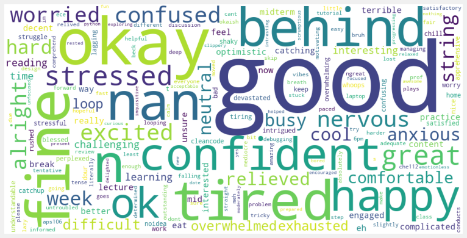

```python
#a word cloud is generated to show the most frequently appearing words
word_text = str((combined_df['comment_one_word'].values))
word_text = word_text.lower()

#remove extra characters
extra_chars = ["xa0","\n","'"]

for char in extra_chars:
    word_text = word_text.replace(char,"")

# define word cloud
stopwords = set(STOPWORDS)
wordcloud = WordCloud(stopwords=stopwords, background_color="white", collocations=False, width=1000, height=500).generate(word_text)
plt.figure(figsize=(12,8))
plt.imshow(wordcloud)
plt.axis("off")

plt.show()
```

# Sentiment Analysis: Look at "One Comment" Responses from Students

```python
# describe the observed polarity
combined_df[['polarity']].describe()
```

|  | polarity |
| --- | --- |
| count | 390.000000 |
| mean | 0.645128 |
| std | 1.387648 |
| min | -3.000000 |
| 25% | 0.000000 |
| 50% | 0.800000 |
| 75% | 1.900000 |
| max | 4.700000 |

```python
print("Most positive feedback, Week 1:")
for text in combined_df.sort_values('polarity').tail(7)['comment_one_word']:
    print('\n  ', text)
```

[output not shown]

```python
print("Most negative feedback, Week 1:")
for text in combined_df.sort_values('polarity').head(6)['comment_one_word']:
    print('\n  ', text)
```

[output not shown]

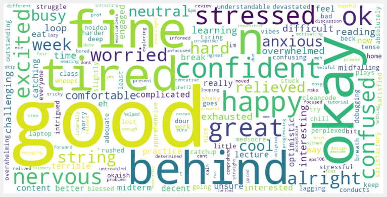

```python
#a word cloud is generated to show the most frequently appearing words
word_text = str((combined_df['comment_one_word'].values))
word_text = word_text.lower()

#remove extra characters
extra_chars = ["xa0","\n","'","nan"]

for char in extra_chars:
    word_text = word_text.replace(char,"")

# define word cloud
stopwords = set(STOPWORDS)
long_answer_words = WordCloud(stopwords=stopwords, background_color="white", collocations=False, width=1000, height=500).generate(word_text)
plt.figure(figsize=(12,8))
plt.imshow(long_answer_words)
plt.axis("off")

plt.show()
```

[figure not shown]

```python
# how many students attended more than one instructor session last week (i.e. both Kinsella and Rosu lectures)
plt.figure(figsize=(7,7))
plt.title("Top 10 Most Commonly Appearing Words in Reflections")

name = list(dict(long_answer_words.words_).keys())[0:5] + list(dict(long_answer_words.words_).keys())[6:12]
values = list(dict(long_answer_words.words_).values())[0:5] + list(dict(long_answer_words.words_).values())[6:12]

plt.barh(name, values)
plt.show()
```

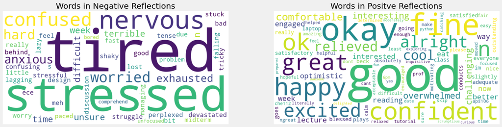

```python
# most commonly appearing words in different polarity reflections
filt = [combined_df[combined_df['polarity']<0], combined_df[combined_df['polarity']>0]]
title = ["Words in Negative Reflections", "Words in Positve Reflections"]

fig, ax = plt.subplots(1,2, figsize=(20, 20))

for index, df in enumerate(filt):

    word_text = str((df['comment_one_word'].values))
    word_text = word_text.lower()

    #remove extra characters
    extra_chars = ["xa0","\n","'","nan"]

    for char in extra_chars:
        word_text = word_text.replace(char,"")

    # define word cloud
    stopwords = set(STOPWORDS)
    words = WordCloud(stopwords=stopwords, background_color="white", collocations=False, width=1000, height=500).generate(word_text)
    ax[index].imshow(words)
    ax[index].set_title("{}".format(title[index]))
    ax[index].axis("off")

plt.show()
```

# List of Topics Students are Confused With

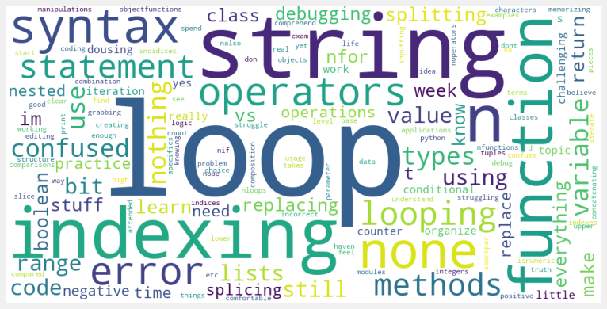

```python
#a word cloud is generated to show the most frequently appearing words
word_text = str((combined_df['confused_topics'].values))
word_text = word_text.lower()

#remove extra characters
extra_chars = ["xa0","\n","'","nan",]

for char in extra_chars:
    word_text = word_text.replace(char,"")

# define word cloud
stopwords = set(STOPWORDS)
confused_topics_words = WordCloud(stopwords=stopwords, background_color="white", collocations=False, width=1000, height=500).generate(word_text)
plt.figure(figsize=(12,8))
plt.imshow(confused_topics_words)
plt.axis("off")

plt.show()
```

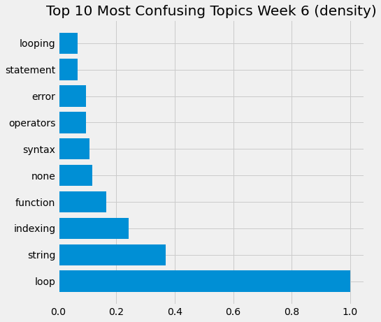

```python
# how many students attended more than one instructor session last week (i.e. both Kinsella and Rosu lectures)
plt.figure(figsize=(7,7))
plt.title("Top 10 Most Confusing Topics Week {} (density)".format(week))

name = list(dict(confused_topics_words.words_).keys())[0:3] + list(dict(confused_topics_words.words_).keys())[4:11]
values = list(dict(confused_topics_words.words_).values())[0:3] + list(dict(confused_topics_words.words_).values())[4:11]

plt.barh(name, values)
plt.show()
```